# DS Survey: Initial Findings

James R Wolman

17/11/2018

```r
# Init
library(readr)
library(tidyr)
library(dplyr)
library(stringr)
library(jsonlite)
library(ggplot2)
library(wesanderson)
library(scales)
```

With packages loaded we can import the survey data. The survey schema contains the questions, the other the multiple choice responses.

## Data Import

```r
# Read in dataset
survey_schema <- format_survey_schema("./DATA/kaggle-survey-2018/SurveySchema.csv")
multiple_choice_responses <- read_csv("./DATA/kaggle-survey-2018/multipleChoiceResponses.csv", progress = FALSE) %>%
        filter(row_number() > 1) # remove question label row

# Remove any columns with user-entered text
cols <- colSums(mapply(grepl, ".* - Text$", multiple_choice_responses))
responses_mcq <- multiple_choice_responses[, which(cols == 0)]
```

## Theme 1: Bias

Discordant relationship between ideal and practice.

Everybody says they want fair and unbiased models but nobody is putting in the work.

Why is this?

A naivety around younger professionals?

We can see this reflected in students who have a lack of opinion on the topic

Do the tools used by those combatting bias differ?

Average age by role and how that affects bias

### Q41: How do you perceive the importance of fairness and bias in ML algos?

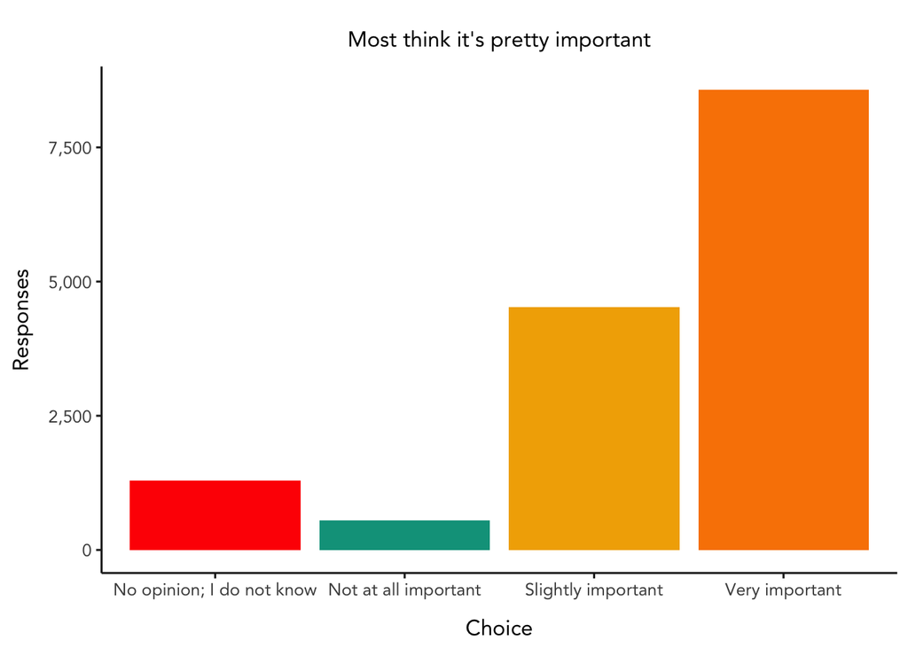

This doesn’t vary much between data scientists, students and other roles.

The data does lean towards the issue being slightly more important to data scientists though.

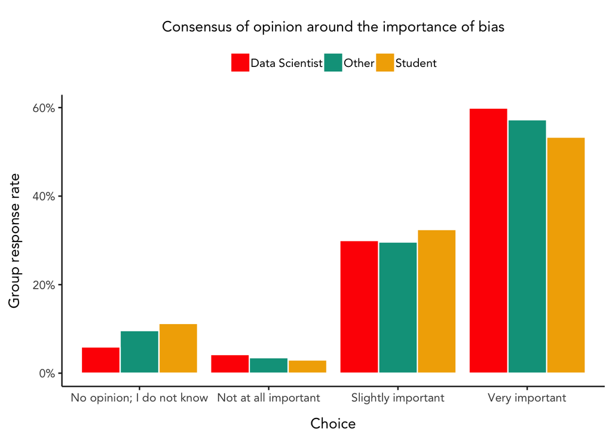

Maybe we find age has something to do with it?

Does the importance of bias and fairness change with age?

[figure not shown]

### Age affects bias

The average age of a data scientist

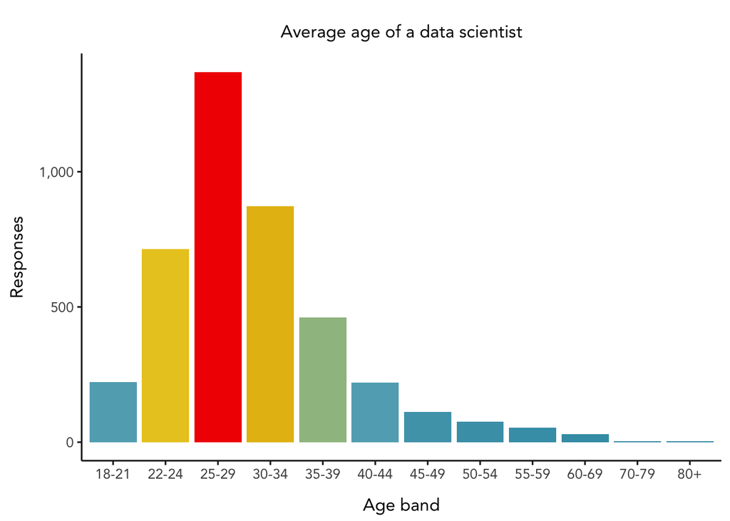

Age affects how we see bias.

There is naivety in youth.

[figure not shown]

Bias is inherent to life and social sciences because of the strong human component.

It is from these disciplines that DS often learn about statistics, and hypothesis-led experimentation. They learn what a fair test and the rigorous standards for disproving a null hypothesis.

It’s a different way of thinking to the computer scientist who builds the modern world as opposed to merely studying it.

Just as the data scientist is a multi-disciplinary unicorn never stemming from a single background so is the way forward.

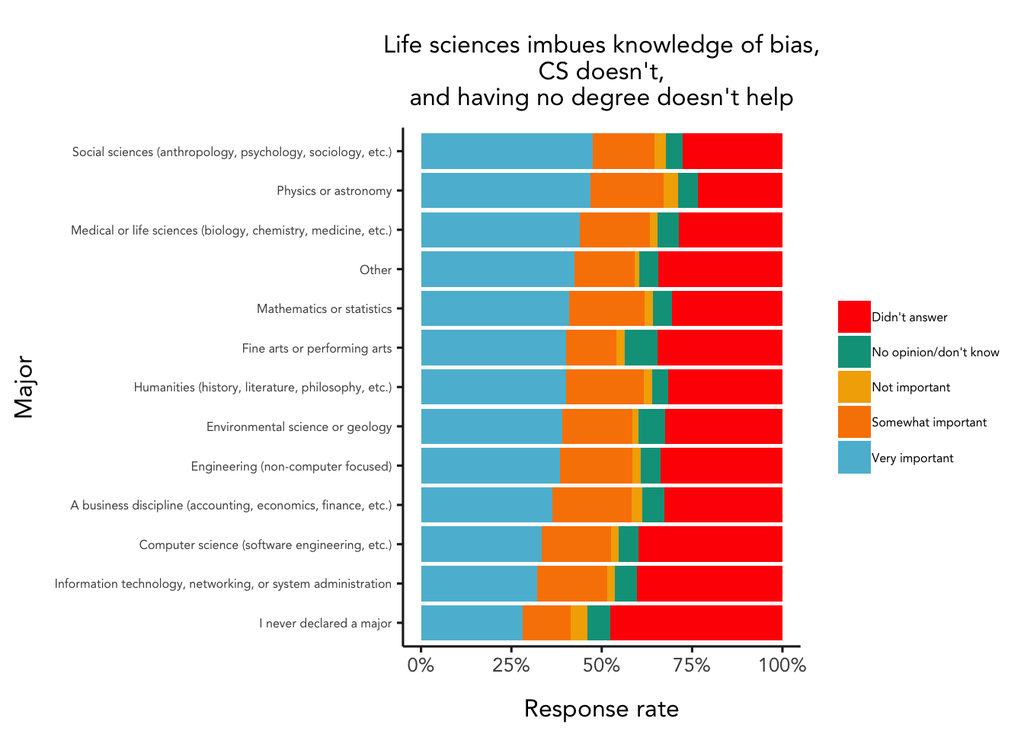

### Tools and the problems they use to deal with it

What people find most difficult about keeping their algorithms fair and unbiased and the tools they use

Firstly, what do they find most difficult?

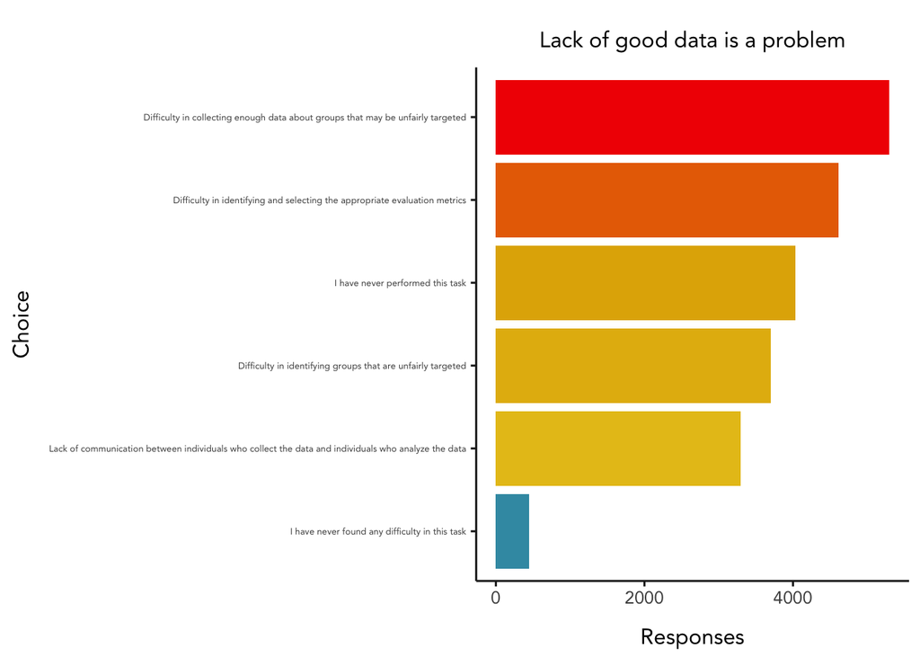